# Static and Context-Specific eQTL Calling with mashR

```r
library(mashr)
library(corrplot)
library(tidyverse)
library(rmeta)
```

## Quality Control

How many cells do we have per cell type and per individual?

[figure not shown]

```r
sample_summary <- read_tsv("/project2/gilad/jpopp/ebQTL/data/static/highpass_cellid_all/pseudobulk-scran/sample_summary_manual.tsv") %>%
  mutate(individual=factor(individual), type=factor(type))
sample_summary %>%
  arrange(n_cells) %>%
  ggplot(aes(x=individual, y=n_cells)) +
  geom_bar(stat="identity") +
  facet_grid(rows=vars(type), scales="free_y") +
  theme(axis.text.x = element_text(angle = 45, hjust=1))
```

For each cell type, how many individuals have at least 5 cells? (This is the cutoff for having a pseudobulk sample)

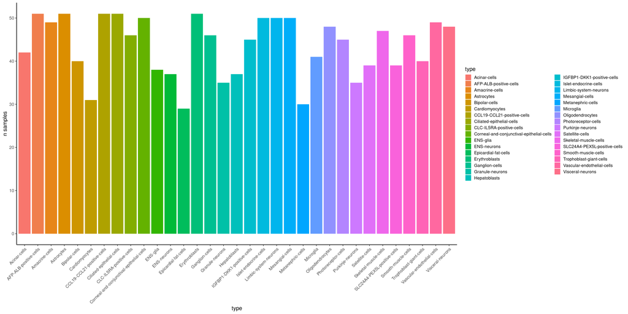

```r
ct_summary <- read_tsv("/project2/gilad/jpopp/ebQTL/data/static/highpass_cellid_all/pseudobulk-scran/samples_per_celltype.tsv") %>%
  mutate(type=factor(type))
ct_summary  %>%
  ggplot(aes(x=type, y=n, fill=type)) +
  geom_bar(stat="identity") +
  ylab("n samples") +
  theme_classic(base_size=15) +
  theme(axis.text.x = element_text(angle = 45, hjust=1))
```

## Understanding Data-Driven Regulatory Patterns

```r
m <- readRDS("/project2/gilad/jpopp/ebQTL/results/static/highpass_cellid_all/pseudobulk-scran/mashr.tophits.rds")
```

[figure not shown]

```r
get_pairwise_sharing(m) %>%
  corrplot(is.corr=F, order='hclust', tl.pos='lt')
```

```r
sum(get_n_significant_conditions(m) >= 1)
```

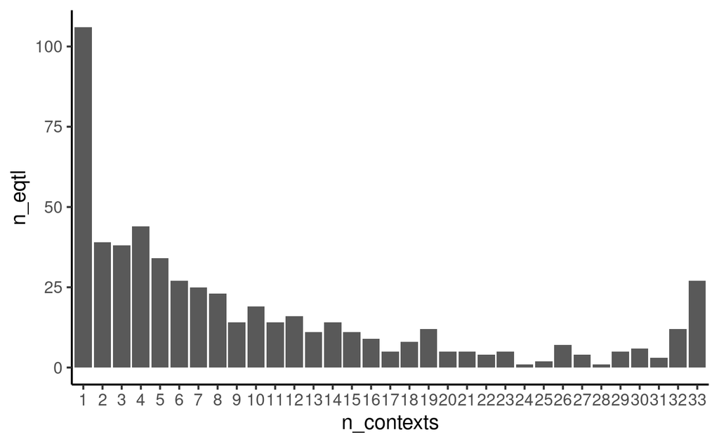

```r
tibble(n_contexts=get_n_significant_conditions(m)) %>%
  filter(n_contexts >= 1) %>%
  dplyr::count(n_contexts, name="n_eqtl") %>%
  mutate(n_contexts=factor(n_contexts, levels=seq(1, ncol(m$result$lfsr)))) %>%
  ggplot(aes(x=n_contexts, y=n_eqtl)) +
  geom_bar(stat="identity") +
  theme_classic(base_size=15)
```

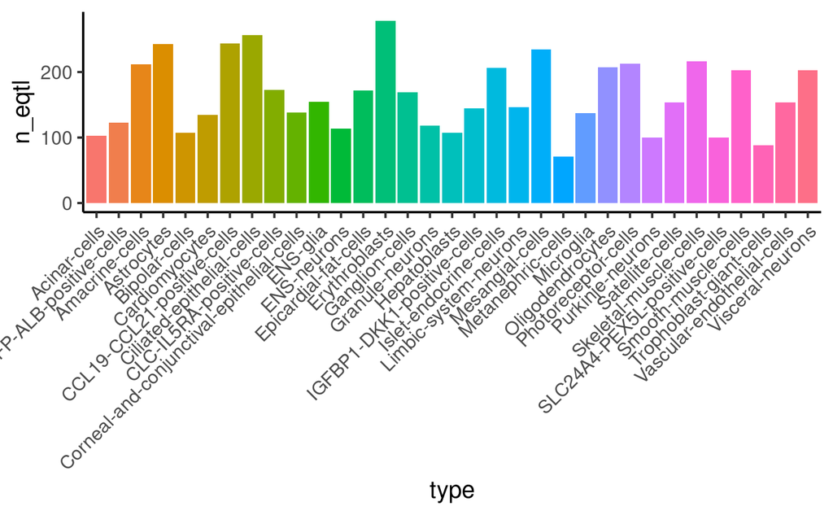

```r
n_qtl <- colSums(m$result$lfsr <= 0.05)

qtl_by_type <- tibble(type=names(n_qtl), n_eqtl=n_qtl)  %>%
  arrange(n_qtl)

ggplot(qtl_by_type, aes(x=type, y=n_eqtl, fill=type)) +
  geom_bar(stat="identity") +
  theme_classic(base_size=15) +
  theme(axis.text.x = element_text(angle=45, hjust=1), legend.position="none")
```

[figure not shown]

```r
ggplot(qtl_by_type, aes(x=type, y=n_eqtl)) +
  geom_segment( aes(x=type, xend=type, y=0, yend=n_eqtl), color="skyblue") +
  geom_point( color="blue", size=8, alpha=0.6) +
  theme_light(base_size=25) +
  coord_flip() +
  theme(
    panel.grid.major.y = element_blank(),
    panel.border = element_blank(),
    axis.ticks.y = element_blank()
  ) +
  ylab("# Genes with eQTL") + xlab("FCA-Annotated Cell Type")
```

```r
tibble(n_contexts=get_n_significant_conditions(m)) %>%
  filter(n_contexts >= 1) %>%
  nrow(.)
```

Now, of the eQTLs that are specific to one context, which context is it?

```r
m$result$lfsr %>%
  as_tibble(rownames="gv") %>%
  pivot_longer(-gv, names_to="type", values_to="lfsr") %>%
  filter(lfsr<=0.05) %>%
  group_by(gv) %>%
  dplyr::select(-lfsr) %>%
  nest() %>%
  mutate(n_contexts=sapply(data, nrow)) %>%
  filter(n_contexts==1) %>%
  unnest(data) %>%
  mutate(type=factor(type)) %>%
  group_by(type) %>%
  dplyr::count() %>%
  ggplot(aes(x=type, y=n, fill=type)) +
  geom_bar(stat="identity") +
  theme_classic() +
  ylab("# Singleton eQTLs") +
  theme(axis.text.x = element_text(angle = 45, hjust=1))
```

[output not shown]

### What are the strongest patterns?

```r
as_tibble(get_estimated_pi(m), rownames="component") %>%
  mutate(component=factor(component, levels=names(get_estimated_pi(m)))) %>%
  ggplot(aes(x=component, y=value)) +
  geom_bar(stat="identity") +
  scale_x_discrete(limits=rev) +
  xlab("Regulatory Pattern") +
  ylab("Weight") +
  coord_flip() +
  theme_classic(base_size = 20)
  #theme(axis.text.x = element_text(angle = 45, hjust=1))
```

Show more interesting covariance matrices

```r
germ_layer <- read_csv("/project2/gilad/katie/ebQTL/FetalReferenceCellTypes_GermLayerAnnotations.csv", col_select = -c(Notes)) %>%
  rename(celltype=`cell type`, layer=`Germ layer`) %>%
  group_by(celltype) %>% add_count() %>%
  mutate(layer=if_else(n > 1, "Ambiguous", layer)) %>%
  dplyr::select(celltype, layer) %>%
  distinct() %>%
  mutate(layer=factor(layer, levels=c("Ambiguous", "Ectoderm", "Neural crest", "Endoderm", "Mesoderm"))) %>%
  mutate(celltype=str_replace_all(celltype, c(" "="-", "_"="-")))

germlayer_levels <- c("Ambiguous", "Ectoderm", "Neural crest", "Endoderm", "Mesoderm")
germlayer_colors <- c("#D5D5D5", "#0076BA", "#006C65", "#FEAE00", "#A62228")
```

```r
m$fitted_g$Ulist$ED_tPCA %>%
  corrplot(is.corr=F)

pc1 <- m$fitted_g$Ulist$ED_tPCA %>%
  princomp %>%
  .$loadings %>%
  .[,1] %>%
  as_tibble(rownames="celltype") %>%
  left_join(germ_layer, by="celltype")

pc1 %>%
  ggplot(aes(x=celltype, y=value, fill=layer)) +
  geom_bar(stat="identity") +
  scale_fill_manual(values=germlayer_colors) +
  coord_flip() +
  theme_classic()
```

```r
pc1 <- m$fitted_g$Ulist$ED_tPCA %>%
  princomp %>%
  .$loadings %>%
  .[,1] %>%
  as_tibble(rownames="celltype") %>%
  left_join(germ_layer, by="celltype")

pc1 %>%
  ggplot(aes(x=celltype, y=value, fill=layer)) +
  geom_bar(stat="identity") +
  scale_fill_manual(values=germlayer_colors) +
  coord_flip() +
  theme_classic()

pc2 <- m$fitted_g$Ulist$ED_tPCA %>%
  princomp %>%
  .$loadings %>%
  .[,2] %>%
  as_tibble(rownames="celltype") %>%
  left_join(germ_layer, by="celltype")

pc2 %>%
  ggplot(aes(x=celltype, y=value, fill=layer)) +
  geom_bar(stat="identity") +
  scale_fill_manual(values=germlayer_colors) +
  coord_flip() +
  theme_classic()
```

```r
m$fitted_g$Ulist$ED_PCA_1 %>%
  corrplot(is.corr=F)

m$fitted_g$Ulist$ED_PCA_1 %>%
  princomp %>%
  .$loadings %>%
  .[,1] %>%
  as_tibble(rownames="type") %>%
  #mutate(type=factor(type, levels=type_levels)) %>%
  ggplot(aes(x=type, y=value, fill=type)) +
  geom_bar(stat="identity") +
  theme_classic(base_size=15) +
  theme(axis.text.x = element_text(angle=30, hjust=1), legend.position="none") +
  xlab("Cell Type") + ylab("Weight")
```

## Examining Context-Specific eQTLs

```r
tests <- rownames(get_lfsr(m))
sighits <- get_significant_results(m)
ident <- as_tibble(m$posterior_weights) %>%
  rowid_to_column() %>%
  filter(rowid %in% sighits) %>%
  pivot_longer(-rowid, names_to="component", values_to="weight") %>%
  group_by(rowid) %>%
  slice_max(weight) %>%
  mutate(component=str_extract(component, "[^.]+")) %>%
  filter(component=="ED_tPCA") %>%
  pull(rowid)

celltype.colors <- germ_layer %>%
  left_join(tibble(layer=germlayer_levels, color=germlayer_colors), by="layer") %>%
  arrange(celltype) %>%
  filter(celltype %in% colnames(m$result$lfsr)) %>%
  pull(color)

mash_plot_meta(m, ident[1], colors=meta.colors(box=celltype.colors))
mash_plot_meta(m, ident[2], colors=meta.colors(box=celltype.colors))
mash_plot_meta(m, ident[3], colors=meta.colors(box=celltype.colors))
mash_plot_meta(m, ident[4], colors=meta.colors(box=celltype.colors))
mash_plot_meta(m, ident[5], colors=meta.colors(box=celltype.colors))
mash_plot_meta(m, ident[6], colors=meta.colors(box=celltype.colors))
mash_plot_meta(m, ident[7], colors=meta.colors(box=celltype.colors))
```

## Shared eQTL Effects

Next, we want to see how many eQTL effects are shared across all of our contexts.

We trained a (univariate) `ash` model on the same set of tests used for our `mash` analysis.

```r
ash_tophits <- readRDS("/project2/gilad/jpopp/ebQTL/results/static/highpass_cellid_all/pseudobulk-scran/ashr.tophits.rds")
sum(ash_tophits$result$lfsr <= 0.05)
```

```r
as_tibble(ash_tophits$result) %>%
  mutate(t=betahat/sebetahat, signif=(lfsr <= 0.05)) %>%
  ggplot(aes(x=t, fill=signif)) +
  geom_histogram(bins=100) +
  theme_classic()
```

## Comparing shared and specific regulatory effects

How many of our context-specific regulatory effects overlap with shared effects?

This would suggest that at these loci the effect *size* varies, though the effect is always present.

```r
sp_eqtls <- tibble(gv=names(get_significant_results(m))) %>%
  separate(gv, into=c("gene", "snp"), sep="--", remove=F)

sh_eqtls <- tibble(gv=names(ash_tophits$data$x), lfsr=get_lfsr(ash_tophits)) %>%
  filter(lfsr <= 0.05) %>%
  dplyr::select(gv) %>%
  separate(gv, into=c("gene", "snp"), sep="--", remove=F)

length(intersect(sh_eqtls$gv, sp_eqtls$gv))
```

Next, I’d like to see how many of these were detected in GTEx. First, I will load all GTEx lead variants.